# Tutorial 2: Accompanying Document

Zayd

17/01/2022

## Introduction:

This document will be accompanying the R-example for Tutorial-2. Use this code to explore how I can use some of the functions to get different values and objects that I need to do the necessary calculations. This way you do not have to calculate everything by hand or compute everything from first principles. This is particularly useful when we need things like residuals and fitted values.

Fitting the regression model using the formula.

```r
y = data$Ext
x = data$Force

ybar = mean(y)
xbar = mean(x)

SSxy = sum((y-ybar)*(x-xbar))
SSxx = sum((x-xbar)^2)

b1_hat = SSxy/SSxx
b0_hat = ybar-b1_hat*xbar
```

## Fit using $\mathtt{lm()}$

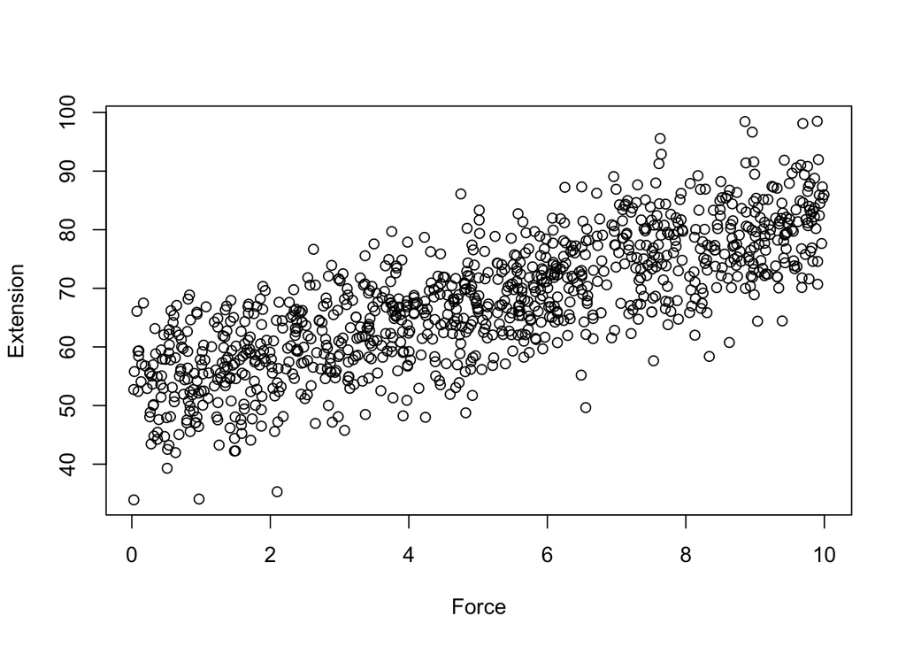

```r
plot(x,y, xlab = "Force", ylab = "Extension")
```

```r
fit = lm(y~x)
summary(fit)
```

```
##
## Call:
## lm(formula = y ~ x)
##
## Residuals:
##      Min       1Q   Median       3Q      Max
## -23.5549  -4.6070   0.2093   4.7130  20.1347
##
## Coefficients:
##             Estimate Std. Error t value Pr(>|t|)
## (Intercept) 52.55766    0.43915  119.68   <2e-16 ***
## x            2.99791    0.07619   39.35   <2e-16 ***
## ---
## Signif. codes:  0 '***' 0.001 '**' 0.01 '*' 0.05 '.' 0.1 ' ' 1
##
## Residual standard error: 6.861 on 998 degrees of freedom
## Multiple R-squared:  0.608,  Adjusted R-squared:  0.6076
## F-statistic:  1548 on 1 and 998 DF,  p-value: < 2.2e-16
```

What can we say about estimates from our formula vs the estimates provided by $\mathtt{R}$?

## Fitted Line

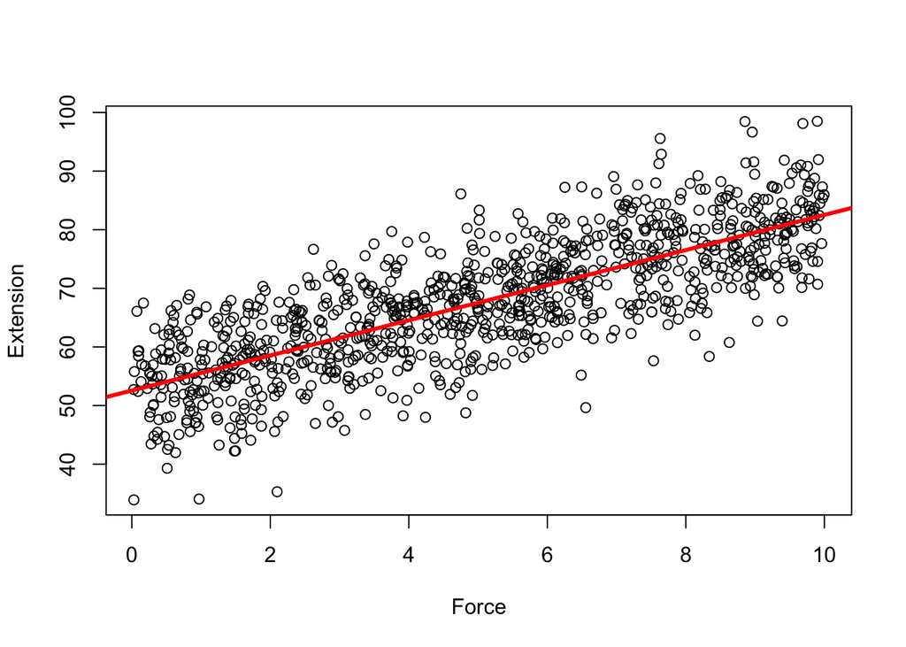

```r
plot(x,y, xlab = "Force", ylab = "Extension")
abline(a=fit$coefficients[1],b=fit$coefficients[2], col = "red",lwd = 3)
```

## Residual Plot

Recall that a key assumption that we are making when fitting these simple linear regression models is that the errors are and are have mean 0. For inferential purposes we sometimes make a stronger assumption that the errors are also Normally-distributed. However, for least squares method to work normality is not required.

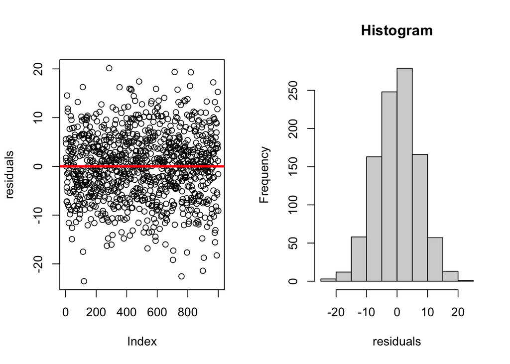

```r
fit_resid = fit$residuals
par(mfrow = c(1,2))
plot(fit_resid, ylab="residuals")
abline(h=0, col = "red", lwd = 3)

hist(fit_resid, xlab="residuals",main = "Histogram")
```

## Estimate of variances:

```r
SSE = sum((y-fit$fitted.values)^2)
n = length(y)
df = n-2


sigma2_hat = SSE/df



## Standard Error of the coeficient parameters

sigma_b1 = sqrt(sigma2_hat/SSxx)

sigma_b0 = sqrt(sigma2_hat*(1/n+xbar^2/SSxx))
```

## Hypothesis Test

We do the hypothesis $H_0:\beta_1=0$ vs $H_1:\beta_1 \neq 0$.

Recall that the statistic that we are using is given by,
$$Z = \frac{\hat{\beta}_1-0}{\sigma_{\hat{\beta}_1}}$$

We also need to specify a distribution to be used. If we assume here that the errors are normally distributed then we can use that fact and then use a Z-table or T-table to obtain the critical values. In our case since $n$ is fairly large, we can directly use the critical values from the Z-table.

Question: Why are we specifically testing this hypothesis? What does a rejection or failure to rejection tell us?

```r
Z = b1_hat/sigma_b1

# Also need the critical value
crti_val = qnorm(0.975)
```

We reject the null hypothesis.

## Finding the sums of Squares

```r
SST = sum((y-ybar)^2)
SSE = sum((y-fit$fitted.values)^2)
SSReg = sum((fit$fitted.values-ybar)^2)
```

## Anova

```r
anova(fit)
```

```
## Analysis of Variance Table
##
## Response: y
##            Df Sum Sq Mean Sq F value    Pr(>F)
## x           1  72882   72882  1548.1 < 2.2e-16 ***
## Residuals 998  46984      47
## ---
## Signif. codes:  0 '***' 0.001 '**' 0.01 '*' 0.05 '.' 0.1 ' ' 1
```